# Intro to Epigenomics (Day 1)

### Learning Outcomes

- You will learn several types of epigenomic regulation and data
- You will understand how epigenomic sequencing data is processed for analysis
- Practice generating reading in count data into R and performing differential peak analysis

## The central dogma of biology

[figure not shown]

> ℹ️ Adapted from Namec et al (2021) Nat Rev

The **central dogma of molecular biology** has long reigned as the transformation of DNA to RNA (transcription) and from RNA to Protien (translation). We now know that proteins can interact with DNA to modulate the production of RNAs via trans-regulation. Simimarly, modifcations to the DNA (i.e. DNA methylation, histone tail modifications) work via cis-regulation to modulate the production of RNAs. Further we will discuss different levels of epigentic control of the transcription.

## What is Epigenomics?

**Epigenomics** is the study of molecular elements that regulate gene expression. The word Epigenome roughly translates to “on top of the genome” with “Epi” meaning top. Put simply, its the study of what is on our DNA. Historically, this has been studied by examining various modes of genomic data such as chromatin accessibility, Transcription Factor (TF) binding, mdifications to the DNA (i.e. DNA methylation, histone tail modifications), and the overla 3D conformation of the genome. Each of these layers have some functional role underlying the ability for RNAPolII to bind to promoters and initiate transcription.

### Chromatin Accesibilty

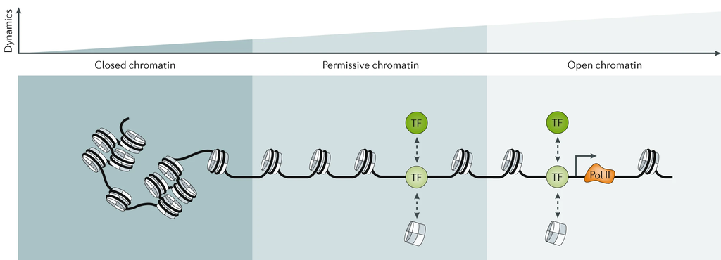

> ℹ️ Adapted from Klemm et al (2019) Nat Rev

The DNA is wrapped around **nucleosomes** which then can wrap around itself like a tangled telephone cord which leads to a compact chromatin state. Chromatin compaction is throught to be one of the largest driving forces in transcriptip. Transcriptional machinery and other epigenetic factors simply cannot bind the the DNA if the chromatin is “closed” or in a compact **heterochromatin** state.

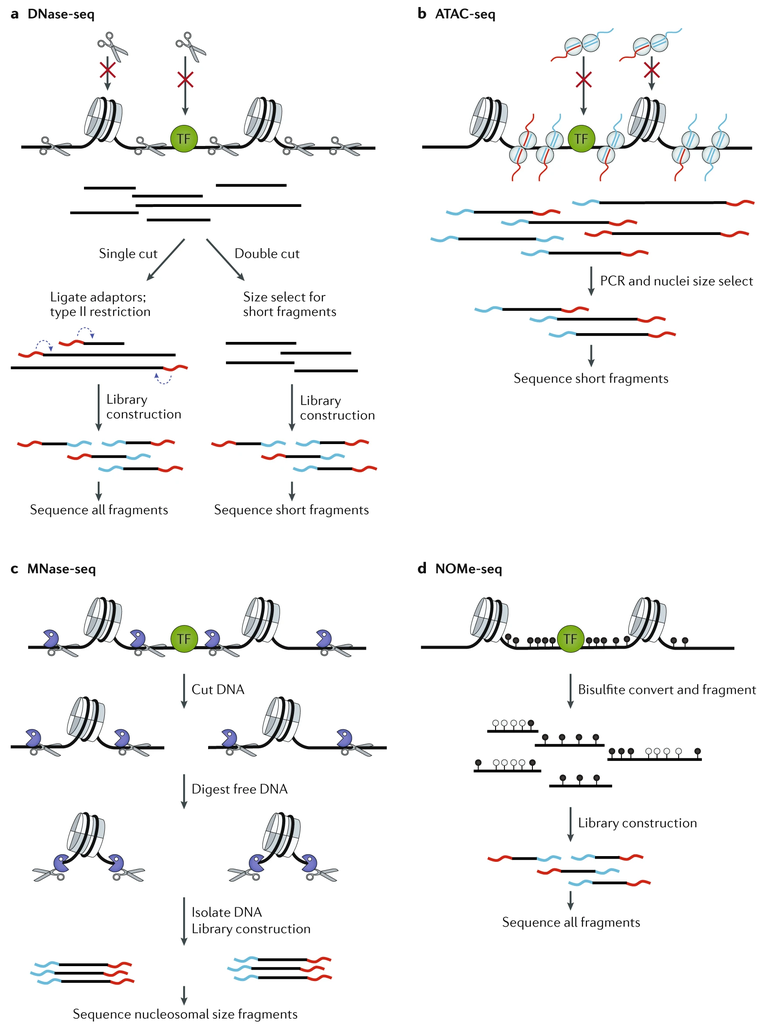

> ℹ️ Adapted from Klemm et al (2019) Nat Rev

Recent and common methods to assay chromatin accessibility are ATAC-seq and DNase-seq. Both methods are able to pull down regions of the genome that are more “open” and the sequencing readouts shows pileups or peaks of areas where the chromatin is accessible.

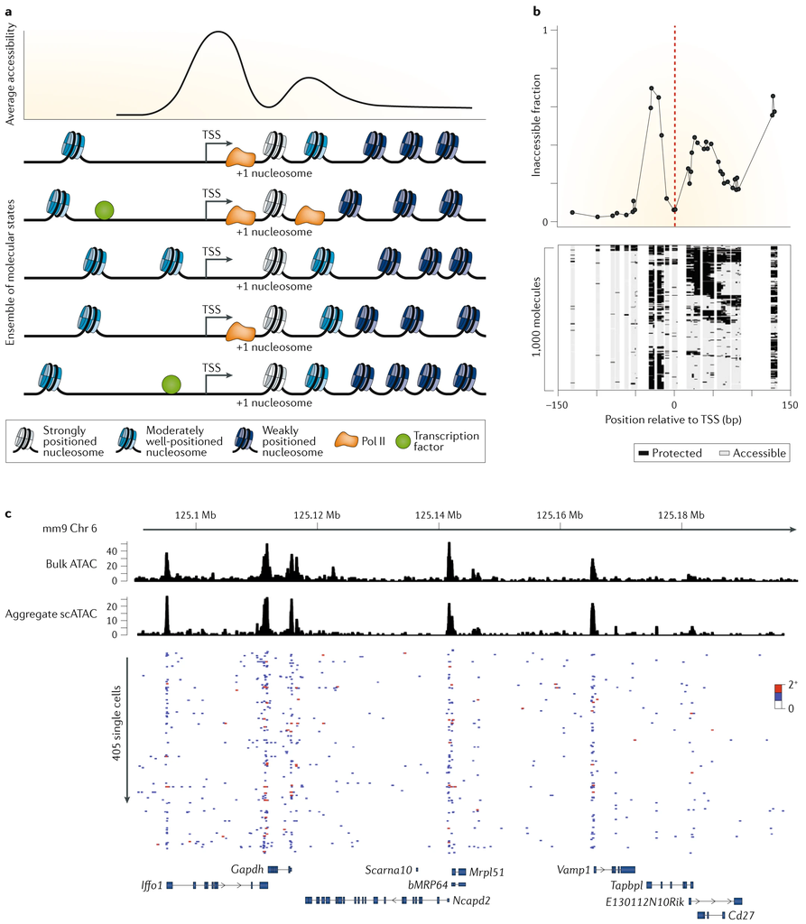

> ℹ️ Adapted from Klemm et al (2019) Nat Rev

| `NOTE` | Methods vary in the way they capture chromatin and careful consideration should be made in determining the method of choice and tools to best analyize the data. |
| --- | --- |